# Olist E-commerce EDA

Sales Structure Analysis

Group 2

2026-06-23

## Objective

The objective is to study the top performers and the products Olist has been struggling to sell.

## 1. Sales Volume and Order Status

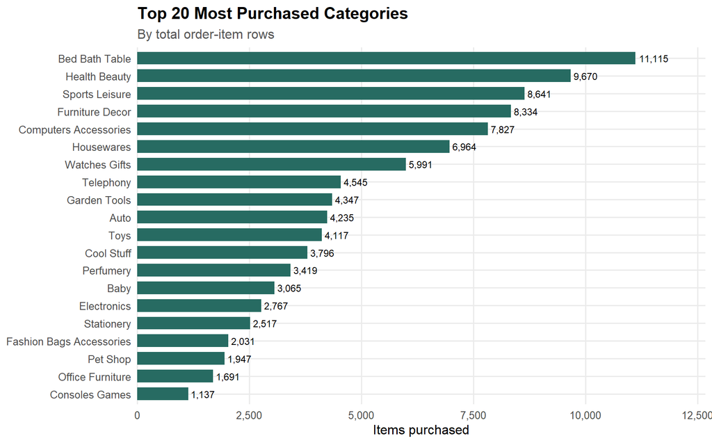

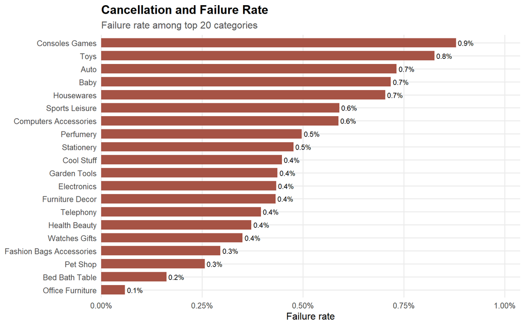

**Interpretation:** High volume identifies commercial demand. Failure rate shows where demand may be leaking because orders are canceled or unavailable.

## 2. Review Sentiment

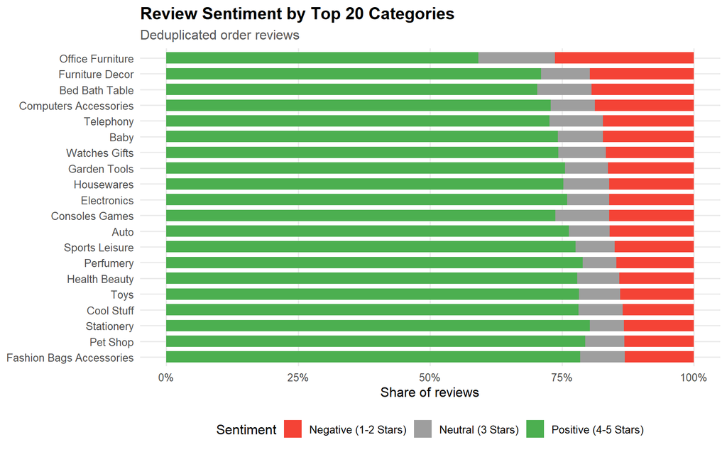

**Interpretation:** Sentiment adds customer experience context to volume. A category can sell well but still create dissatisfaction. From the plot we see that Furniture categories (office and decor) have the highest percentage of negative reviews which would require further analysis.

## 3. Geographic Concentration

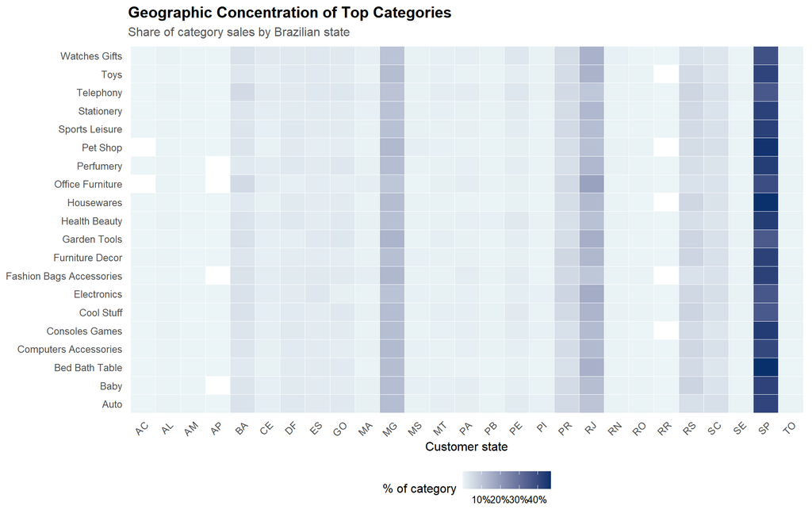

**Interpretation:** Geographic concentration helps Sales decide where to focus seller coverage, stock placement and logistics improvement. From the plots, we see San Paolo has the most orders followed by MG, and RJ.

## 4. Macro Segments and Revenue

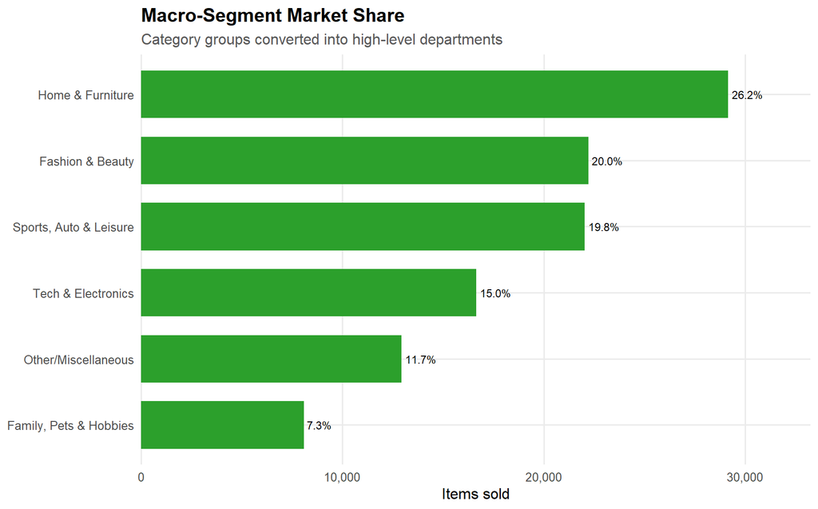

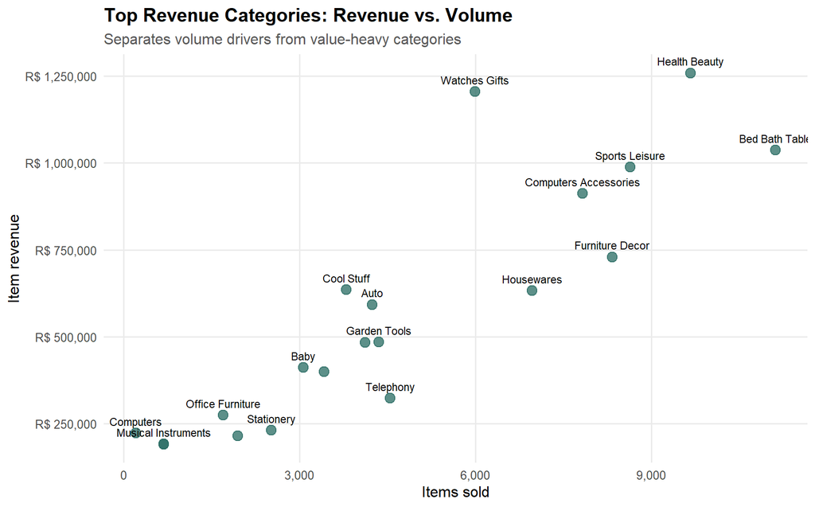

## 5. Freight Burden and Weak-Category Diagnostics

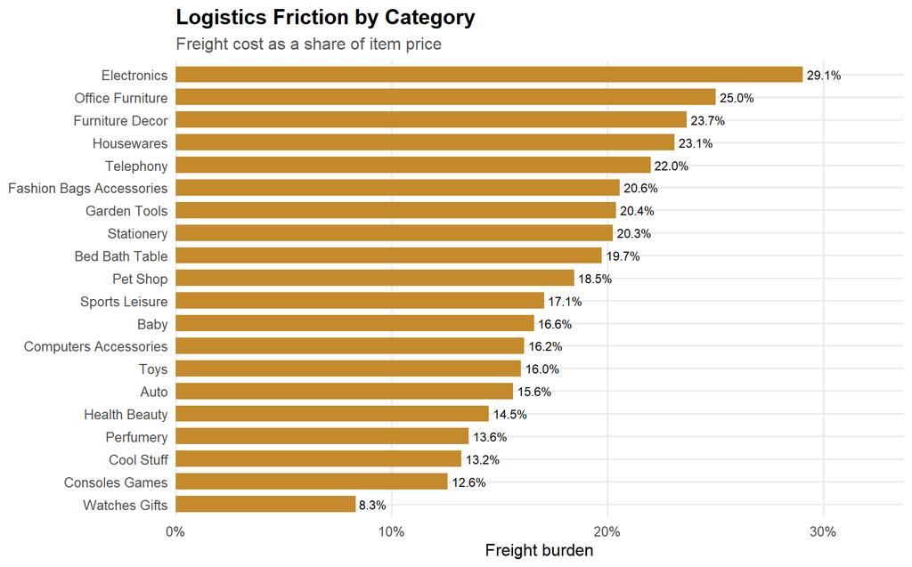

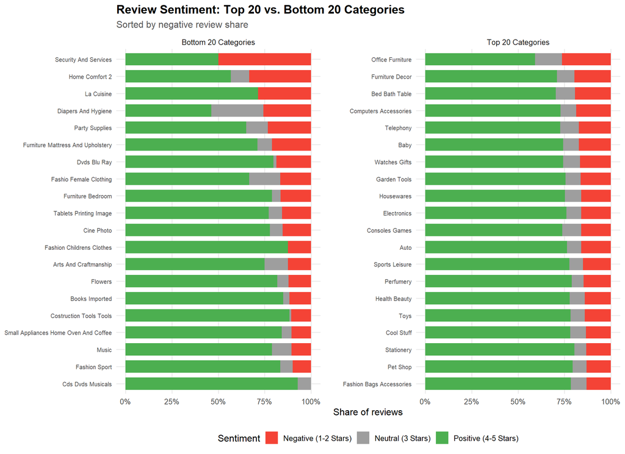

## 6. Delivery, Seller and Seasonality Diagnostics

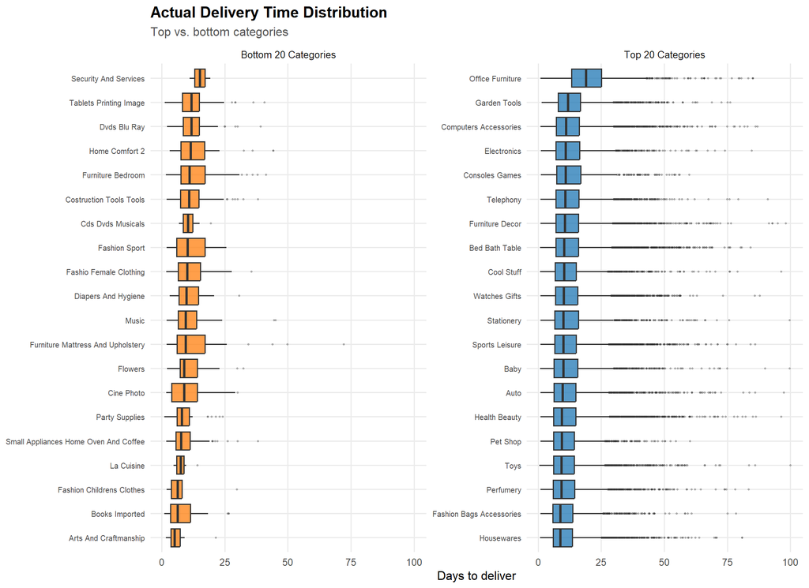

| Metric | review_score | delivery_days | freight_ratio |
| --- | --- | --- | --- |
| review_score | 1.000 | -0.227 | -0.039 |
| delivery_days | -0.227 | 1.000 | 0.120 |
| freight_ratio | -0.039 | 0.120 | 1.000 |

| clean_category | seller_id | total_items_sold | avg_delivery_days |
| --- | --- | --- | --- |
| Costruction Tools Tools | c8467937e403e76a8ee9f0ab13f6f5ef | 33 | 16.7 |
| Tablets Printing Image | e62b2d6ac10570a035a30bafcf01d263 | 20 | 16.2 |
| Fashio Female Clothing | dc8798cbf453b7e0f98745e396cc5616 | 12 | 15.8 |
| Home Comfort 2 | 4a3ca9315b744ce9f8e9374361493884 | 26 | 15.4 |
| Cine Photo | 8d956fec2e4337affcb520f56fd8cbfd | 12 | 15.2 |
| Small Appliances Home Oven And Coffee | f62d7bb4a613ec758a03342d46b580b2 | 19 | 14.5 |
| Furniture Bedroom | 3ade81dab5a172b88e1871c28ae05260 | 27 | 14.1 |
| Dvds Blu Ray | 75fbb52eda0cbc24f479d3b2fbfa8d3e | 41 | 13.9 |
| Furniture Mattress And Upholstery | 00ee68308b45bc5e2660cd833c3f81cc | 22 | 12.4 |
| Flowers | 8bb48dc19fccaa8613b6229bf7f452a2 | 22 | 12.3 |
| Furniture Bedroom | 5b0cc932433fa5184b5b94bfe6bcc256 | 11 | 12.0 |
| Diapers And Hygiene | 270d3ef21830ad0ecf3a6c53d08a533a | 17 | 11.4 |
| Tablets Printing Image | 0db783cfcd3b73998abc6e10e59a102f | 53 | 11.4 |
| Cds Dvds Musicals | 4e922959ae960d389249c378d1c939f5 | 14 | 10.7 |
| Costruction Tools Tools | 8daab2245ebdc277c51098d01c5ad8ef | 11 | 10.6 |
| Small Appliances Home Oven And Coffee | ba90964cff9b9e0e6f32b23b82465f7b | 17 | 10.3 |
| Diapers And Hygiene | 218d46b86c1881d022bce9c68a7d4b15 | 12 | 9.4 |
| Cine Photo | da7039f29f90ce5b4846ffc0fcc93beb | 18 | 8.9 |
| Fashion Sport | e7df4cd29ab5abab70fb0783ddb53987 | 12 | 7.9 |
| Books Imported | 7c5b05cbdb5542049f38d90d7815b97d | 23 | 7.8 |

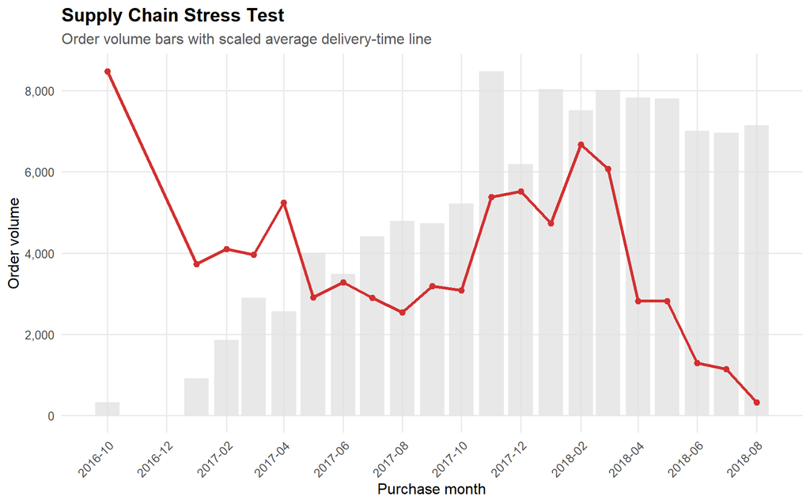

## 7. Transaction Clustering

| cluster_id | total_sales | avg_price | avg_freight | avg_delivery_days | freight_burden_pct |
| --- | --- | --- | --- | --- | --- |
| 1 | 77360 | R$ 80 | R$ 15 | 8.7 | 19.0% |
| 2 | 20594 | R$ 93 | R$ 21 | 24.8 | 23.0% |
| 3 | 10593 | R$ 333 | R$ 42 | 13.5 | 12.7% |

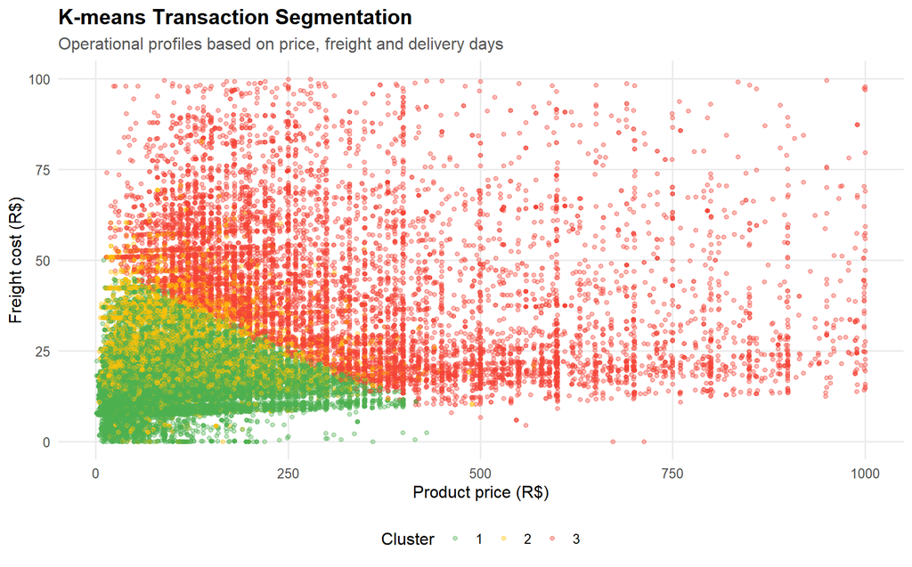

## Business Takeaways

- **Weak categories need diagnosis:** low volume may come from demand, but also from freight friction, reviews, delivery delays or seller issues.
- **Freight burden is a sales lever:** categories where shipping is high relative to product price may benefit from bundling, minimum-order thresholds or logistics renegotiation.
- **Customer experience matters:** review sentiment and delivery variance should be evaluated alongside sales volume before making assortment decisions.